# NYC Trip Analysis

## —————————————————————————————————————————————————————-

# Question 1 >

### Programmatically download and load into our favorite analytical tool the trip data for September 2015.

```r
# Fetch data for September 2015 "Green" cabs using pre-defined function in R
if (file.exists("data.csv") == FALSE) {
  status <- download.file("https://s3.amazonaws.com/nyc-tlc/trip+data/green_tripdata_2015-09.csv", destfile = "data.csv", quiet = TRUE)
}
```

### Report how many rows and columns of data we have loaded.

```r
# read the downloaded dataset and identify its dimensions
data <- read.csv("data.csv")
ncol(data) # Number of columns present in our dataset
```

```
[1] 21
```

```r
nrow(data) # Number of rows present in our dataset
```

```
[1] 1494926
```

```r
summary(data) # We compute a summary of the data present in each column of our dataset - this will help us later
```

```
    VendorID              lpep_pickup_datetime         Lpep_dropoff_datetime Store_and_fwd_flag   RateCodeID     Pickup_longitude Pickup_latitude Dropoff_longitude
 Min.   :1.000   2015-09-20 02:00:32:      9   2015-09-28 00:00:00:    172   N:1486192          Min.   : 1.000   Min.   :-83.32   Min.   : 0.00   Min.   :-83.43
 1st Qu.:2.000   2015-09-05 14:57:48:      8   2015-09-13 00:00:00:    153   Y:   8734          1st Qu.: 1.000   1st Qu.:-73.96   1st Qu.:40.70   1st Qu.:-73.97
 Median :2.000   2015-09-10 17:43:49:      8   2015-09-19 00:00:00:    141                      Median : 1.000   Median :-73.95   Median :40.75   Median :-73.95
 Mean   :1.782   2015-09-13 00:27:28:      8   2015-09-14 00:00:00:    126                      Mean   : 1.098   Mean   :-73.83   Mean   :40.69   Mean   :-73.84
 3rd Qu.:2.000   2015-09-13 01:06:29:      8   2015-09-21 00:00:00:    125                      3rd Qu.: 1.000   3rd Qu.:-73.92   3rd Qu.:40.80   3rd Qu.:-73.91
 Max.   :2.000   2015-09-26 22:48:40:      8   2015-09-12 00:00:00:    119                      Max.   :99.000   Max.   :  0.00   Max.   :43.18   Max.   :  0.00
                 (Other)            :1494877   (Other)            :1494090
 Dropoff_latitude Passenger_count Trip_distance      Fare_amount          Extra            MTA_tax          Tip_amount       Tolls_amount      Ehail_fee
 Min.   : 0.00    Min.   :0.000   Min.   :  0.000   Min.   :-475.00   Min.   :-1.0000   Min.   :-0.5000   Min.   :-50.000   Min.   :-15.2900   Mode:logical
 1st Qu.:40.70    1st Qu.:1.000   1st Qu.:  1.100   1st Qu.:   6.50   1st Qu.: 0.0000   1st Qu.: 0.5000   1st Qu.:  0.000   1st Qu.:  0.0000   NA's:1494926
 Median :40.75    Median :1.000   Median :  1.980   Median :   9.50   Median : 0.5000   Median : 0.5000   Median :  0.000   Median :  0.0000
 Mean   :40.69    Mean   :1.371   Mean   :  2.968   Mean   :  12.54   Mean   : 0.3513   Mean   : 0.4866   Mean   :  1.236   Mean   :  0.1231
 3rd Qu.:40.79    3rd Qu.:1.000   3rd Qu.:  3.740   3rd Qu.:  15.50   3rd Qu.: 0.5000   3rd Qu.: 0.5000   3rd Qu.:  2.000   3rd Qu.:  0.0000
 Max.   :42.80    Max.   :9.000   Max.   :603.100   Max.   : 580.50   Max.   :12.0000   Max.   : 0.5000   Max.   :300.000   Max.   : 95.7500

 improvement_surcharge  Total_amount      Payment_type     Trip_type
 Min.   :-0.3000       Min.   :-475.00   Min.   :1.000   Min.   :1.000
 1st Qu.: 0.3000       1st Qu.:   8.16   1st Qu.:1.000   1st Qu.:1.000
 Median : 0.3000       Median :  11.76   Median :2.000   Median :1.000
 Mean   : 0.2921       Mean   :  15.03   Mean   :1.541   Mean   :1.022
 3rd Qu.: 0.3000       3rd Qu.:  18.30   3rd Qu.:2.000   3rd Qu.:1.000
 Max.   : 0.3000       Max.   : 581.30   Max.   :5.000   Max.   :2.000
                                                         NA's   :4
```

## —————————————————————————————————————————————————————-

# Question 2 >

### Plot a histogram of the number of the trip distance (“Trip Distance”).

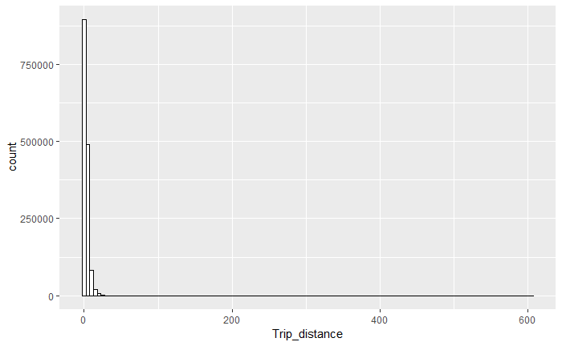

```r
library(ggplot2)
library(dplyr)
# plot a histogram of the trip distances ("Trip Distance")
ggplot(data, aes(x=Trip_distance)) + geom_histogram(binwidth = 5, color="black", fill="white")
```

*Based on the histogram & summary above, we can see that this feature contains outliers - so we find out the standard deviation of this feature.* *Then we only consider the data points that fall within zero to 3 standard deviations away (in terms of range) from the mean (= 2.968 miles).*

```r
sd.trip.distance <- sd(data$Trip_distance)
relevant.data <- subset(data, Trip_distance <= 2.968 + (3*sd.trip.distance))
```

*The above tuned dataset contains most data points (99.7%) from a Trip distance perspective, minus the outliers that made our previous histogram difficult to read.*

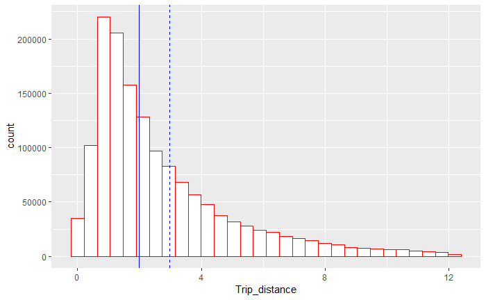

```r
ggplot(relevant.data, aes(x=Trip_distance)) + geom_histogram(color="red", fill="white") + geom_vline(xintercept = 2.968, linetype="dashed", color="blue") + geom_vline(xintercept = 1.98, color="blue")
```

### Report any structure we find and any hypotheses we have about that structure.

*Based on the histogram above, we can infer that the distribution of trip distances is unimodal and essentially right-skewed. The two measures of central tendency, i.e. median (1.98, solid blue line) and mean (2.968, dashed blue line) are plotted on the histogram to provide a better idea of the data.*

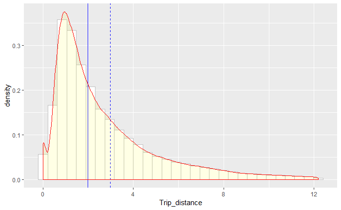

```r
ggplot(relevant.data, aes(x=Trip_distance)) + geom_histogram(aes(y=..density..), color="grey", fill="white") + geom_vline(xintercept = 2.968, linetype="dashed", color="blue") + geom_vline(xintercept = 1.98, color="blue") + geom_density(alpha=0.1, color="red", fill="yellow")
```

*Superimposing a density curve upon the histogram, we can see that the distribution approximates to a lognormal distribution (with sigma value 1).*  
*This distribution is similar to income distributions in society, etc.*

*The general inference here is that most taxi trips are short hauls (less than 4 miles, accounting for 77% of total trips in September) (which makes sense since these are taxis plying within NYC), with 1.05 miles (mode) being the maxima i.e. most of these cabs will travel only 1.05 miles on an average (per journey).*  
*Having said that, we can see that a few taxis (22.63%) do end up traveling more than 4 miles per journey!*

## —————————————————————————————————————————————————————-

# Question 3 >

### Report mean and median trip distance grouped by hour of day.

*Over here, the only columns/fields indicating time (hour) of the day from a taxi trip perspective are lpep.pickup.datetime and Lpep.dropoff.datetime*  
*We shall thus, use both fields and use them for visualizing and reporting mean and median trip distances grouped by hour of day.*

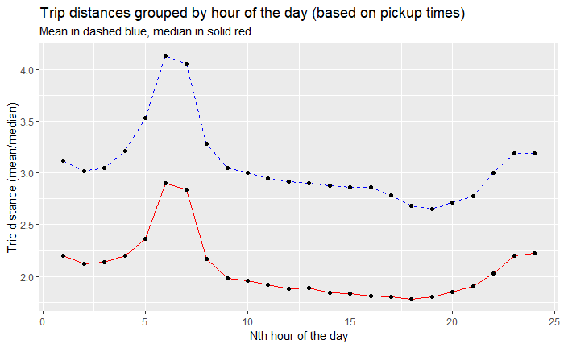

```r
# firstly, we need to convert the datatype of the datetime columns from factor to date-time
data$lpep_pickup_datetime <- as.character(data$lpep_pickup_datetime)
data$lpep_pickup_datetime <- strptime(data$lpep_pickup_datetime, format = "%Y-%m-%d %H:%M:%S") # can use format = "%F %T" for conciseness
data$Lpep_dropoff_datetime <- as.character(data$Lpep_dropoff_datetime)
data$Lpep_dropoff_datetime <- strptime(data$Lpep_dropoff_datetime, format = "%F %T") # performs similar conversion, as above
# choosing the pickup datetime for further analysis and reporting, we seperate the date-time columns into 2 seperate ones - one for date and other for time
# data$pickup_date <- format(data$lpep_pickup_datetime, format = "%F"); data$pickup_date <- strptime(data$pickup_date, format = "%F") # can be removed? unnecessary!
data$pickup_time <- format(data$lpep_pickup_datetime, format = "%T"); data$pickup_time <- as.POSIXct(data$pickup_time, format = "%T")
# data$dropoff_date <- format(data$Lpep_dropoff_datetime, format = "%F"); data$dropoff_date <- strptime(data$dropoff_date, format = "%F") # can be removed? unnecessary!
data$dropoff_time <- format(data$Lpep_dropoff_datetime, format = "%T"); data$dropoff_time <- as.POSIXct(data$dropoff_time, format = "%T")
mean.trp.dst.per.hour.pickup <- aggregate(Trip_distance ~ cut(pickup_time, breaks = "1 hour", labels = FALSE), data = data, FUN = mean)
median.trp.dst.per.hour.pickup <- aggregate(Trip_distance ~ cut(pickup_time, breaks = "1 hour", labels = FALSE), data = data, FUN = median)
trp.dst.per.pickup.hour <- cbind(mean.trp.dst.per.hour.pickup, median.trp.dst.per.hour.pickup[,2])
p1 <- ggplot(trp.dst.per.pickup.hour, aes(x=trp.dst.per.pickup.hour[,1])) + geom_line(aes(y=trp.dst.per.pickup.hour[,2]), linetype="dashed", color="blue") + geom_line(aes(y=trp.dst.per.pickup.hour[,3]), color="red") + geom_point(aes(y=trp.dst.per.pickup.hour[,2])) + geom_point(aes(y=trp.dst.per.pickup.hour[,3]))
p1 + ggtitle("Trip distances grouped by hour of the day (based on pickup times)", subtitle = "Mean in dashed blue, median in solid red") + xlab("Nth hour of the day") + ylab("Trip distance (mean/median)")
```

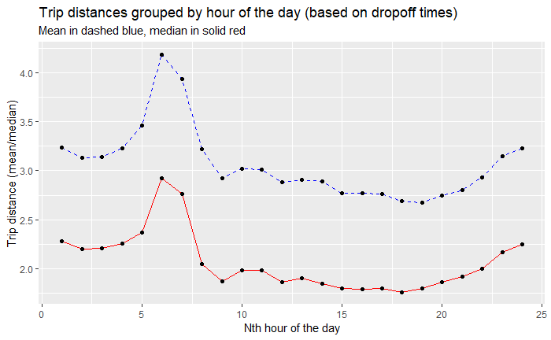

```r
mean.trp.dst.per.hour.dropff <- aggregate(Trip_distance ~ cut(dropoff_time, breaks = "1 hour", labels = FALSE), data = data, FUN = mean)
median.trp.dst.per.hour.dropoff <- aggregate(Trip_distance ~ cut(dropoff_time, breaks = "1 hour", labels = FALSE), data = data, FUN = median)
trp.dst.per.dropoff.hour <- cbind(mean.trp.dst.per.hour.dropff, median.trp.dst.per.hour.dropoff[,2])
p1 <- ggplot(trp.dst.per.dropoff.hour, aes(x=trp.dst.per.dropoff.hour[,1])) + geom_line(aes(y=trp.dst.per.dropoff.hour[,2]), linetype="dashed", color="blue") + geom_line(aes(y=trp.dst.per.dropoff.hour[,3]), color="red") + geom_point(aes(y=trp.dst.per.dropoff.hour[,2])) + geom_point(aes(y=trp.dst.per.dropoff.hour[,3]))
p1 + ggtitle("Trip distances grouped by hour of the day (based on dropoff times)", subtitle = "Mean in dashed blue, median in solid red") + xlab("Nth hour of the day") + ylab("Trip distance (mean/median)")
```

### We’d like to get a rough sense of identifying trips that originate or terminate at one of the NYC area airports. Can we provide a count of how many transactions fit this criteria, the average fare, and any other interesting characteristics of these trips.

*The New York metropolitan area is essentially served by 3 airports (Source: Wikipedia), and we shall consider them all for our analysis, one by one.*

```r
# The co-ordinates for JFK (John F. Kennedy airport) are 40.6413 N, 73.7781 W
jfk.origin <- subset(data, round(Pickup_latitude, digits = 2) == 40.64 & round(Pickup_longitude, digits = 2) == -73.78) # JFK pickups
jfk.terminate <- subset(data, round(Dropoff_latitude, digits = 2) == 40.64 & round(Dropoff_longitude, digits = 2) == -73.78) # JFK dropoffs
# The co-ordinates for LGA (LaGuardia airport) are 40.7769 N, 73.8740 W
lga.origin <- subset(data, round(Pickup_latitude, digits = 2) == 40.78 & round(Pickup_longitude, digits = 2) == -73.87) # LGA pickups
lga.terminate <- subset(data, round(Dropoff_latitude, digits = 2) == 40.78 & round(Dropoff_longitude, digits = 2) == -73.87) # LGA dropoffs
# The co-ordinates for EWR (Newark Liberty International airport) are 40.6895 N, 74.1745 W
ewr.origin <- subset(data, round(Pickup_latitude, digits = 2) == 40.69 & round(Pickup_longitude, digits = 2) == -74.17) # EWR pickups
ewr.terminate <- subset(data, round(Dropoff_latitude, digits = 2) == 40.69 & round(Dropoff_longitude, digits = 2) == -74.17) # EWR dropoffs
trips.to.and.from.airports <- rbind(jfk.origin, jfk.terminate, lga.origin, lga.terminate, ewr.origin, ewr.terminate) # all trips to and from airports
NROW(trips.to.and.from.airports) # Number of transactions fitting this criteria
```

```
[1] 4217
```

```r
mean(trips.to.and.from.airports$Total_amount) # average amount charged to customer(s) in USD, upon completion of trip
```

```
[1] 49.41675
```

*This ($49.41) is quite expensive, since the overall average fare for taxi trips in September 2015 is only $15.03, the median being even lesser at $11.76.*  
*Let’s try to find some more deviating characteristics about such trips - in order to be able to surmise why they might be so expensive compared to regular taxi trips.*

*To begin with, we can find out more such interesting characteristics for these trips.*

```r
summary(trips.to.and.from.airports$Passenger_count) # mean and median passenger counts don't stand out, so this cannot be the reason for the high fare
```

```
   Min. 1st Qu.  Median    Mean 3rd Qu.    Max.
  0.000   1.000   1.000   1.377   1.000   6.000
```

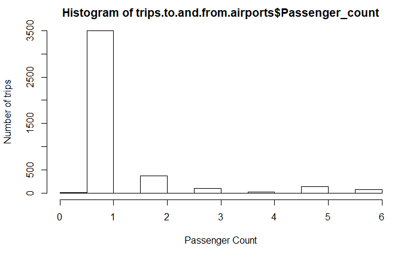

```r
hist(trips.to.and.from.airports$Passenger_count, xlab = "Passenger Count", ylab = "Number of trips")
```

```r
summary(trips.to.and.from.airports$Trip_distance) # in miles, mean(13.81) and median(14.18) trip distances are remarkably high (vs 2.968 and 1.98 respectively, overall)
```

```
   Min. 1st Qu.  Median    Mean 3rd Qu.    Max.
   0.00   11.16   14.18   13.81   17.53   48.75
```

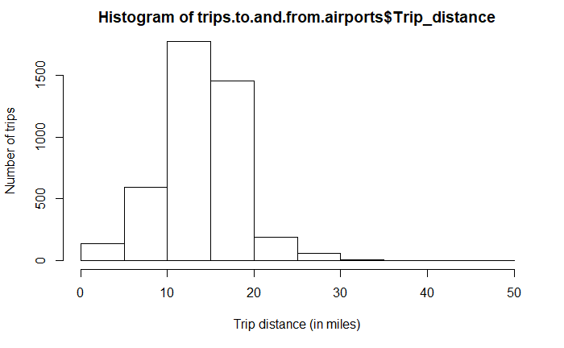

```r
hist(trips.to.and.from.airports$Trip_distance, xlab = "Trip distance (in miles)", ylab = "Number of trips")
```

```r
as.numeric(mean((trips.to.and.from.airports$Lpep_dropoff_datetime - trips.to.and.from.airports$lpep_pickup_datetime)))/60 # mean trip time (in minutes) is 39.3 mins
```

```
[1] 39.31924
```

```r
as.numeric(median((trips.to.and.from.airports$Lpep_dropoff_datetime - trips.to.and.from.airports$lpep_pickup_datetime)))/60 # median trip time (in minutes) is 33.4 mins
```

```
[1] 33.41667
```

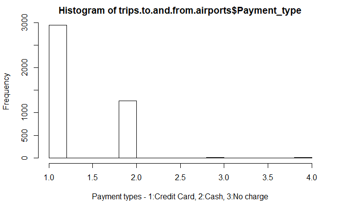

```r
hist(trips.to.and.from.airports$Payment_type, xlab = "Payment types - 1:Credit Card, 2:Cash, 3:No charge") # as we can see, most customers prefer to pay using their credit cards
```

*Thus, to conclude, the higher fares paid by passengers travelling to and from airports are most probably a direct consequence of longer trip distances and durations.*

## —————————————————————————————————————————————————————-

# Question 4 >

### Build a derived variable for tip as a percentage of the total fare.

```r
data$tip.to.fare.pct.ratio <- (data$Tip_amount/data$Total_amount) * 100
# we have to keep in mind that the field Total_amount has 4172 cases with a value of zero. Also, 2417 cases have negative values (less than zero)
# From a tip perspective, we have 38 cases where the Tip_amount is negative (less than zero)
summary(data$tip.to.fare.pct.ratio) # as a result, we have 4172 NA values in our newly generated derived column
```

```
   Min. 1st Qu.  Median    Mean 3rd Qu.    Max.    NA's
  0.000   0.000   0.000   6.654  16.667 100.000    4172
```

### Build a predictive model for tip as a percentage of the total fare. Use as much of the data as we like (or all of it).

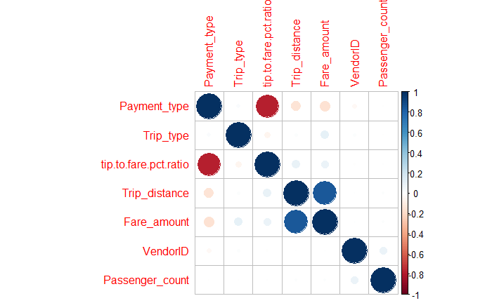

```r
library(corrplot)
data.feats.for.correlation <- select(data, VendorID, Passenger_count, Trip_distance, Fare_amount, Payment_type, Trip_type, tip.to.fare.pct.ratio)
data.cor <- cor(data.feats.for.correlation, use = "complete.obs")
corrplot(data.cor, order = "hclust") # based on this, we can see that 4 variables show some degree of correlation with our response variable (Payment_type being the best)
```

```r
# we shall also go ahead and do best subset selection to identify the best predictors from our set of features present in data
library(leaps)
data$lpep_pickup_datetime <- as.POSIXct(data$lpep_pickup_datetime)    # convert to vector instead of list type (date data type)
data$Lpep_dropoff_datetime <- as.POSIXct(data$Lpep_dropoff_datetime)  # convert to vector instead of list type (date data type)
reg.fss <- regsubsets(tip.to.fare.pct.ratio ~ ., data = data[, -c(12, 15, 17, 19)], nvmax = 23) # exclude incompatible columns, perform selection check
reg.fss.summary <- summary(reg.fss)
reg.fss.summary # the best predictors in order are Payment_type, Trip_type, improvement_surcharge, VendorID, Pickup_longitude & Pickup_latitude, Fare_amount, Trip_distance
```

```
Subset selection object
Call: regsubsets.formula(tip.to.fare.pct.ratio ~ ., data = data[, -c(12,
    15, 17, 19)], nvmax = 23)
19 Variables  (and intercept)
                      Forced in Forced out
VendorID                  FALSE      FALSE
lpep_pickup_datetime      FALSE      FALSE
Lpep_dropoff_datetime     FALSE      FALSE
Store_and_fwd_flagY       FALSE      FALSE
RateCodeID                FALSE      FALSE
Pickup_longitude          FALSE      FALSE
Pickup_latitude           FALSE      FALSE
Dropoff_longitude         FALSE      FALSE
Dropoff_latitude          FALSE      FALSE
Passenger_count           FALSE      FALSE
Trip_distance             FALSE      FALSE
Extra                     FALSE      FALSE
MTA_tax                   FALSE      FALSE
Tolls_amount              FALSE      FALSE
improvement_surcharge     FALSE      FALSE
Payment_type              FALSE      FALSE
Trip_type                 FALSE      FALSE
pickup_time               FALSE      FALSE
dropoff_time              FALSE      FALSE
1 subsets of each size up to 19
Selection Algorithm: exhaustive
          VendorID lpep_pickup_datetime Lpep_dropoff_datetime Store_and_fwd_flagY RateCodeID Pickup_longitude Pickup_latitude Dropoff_longitude Dropoff_latitude
1  ( 1 )  " "      " "                  " "                   " "                 " "        " "              " "             " "               " "
2  ( 1 )  " "      " "                  " "                   " "                 " "        " "              " "             " "               " "
3  ( 1 )  " "      " "                  " "                   " "                 " "        " "              " "             " "               " "
4  ( 1 )  "*"      " "                  " "                   " "                 " "        " "              " "             " "               " "
5  ( 1 )  " "      " "                  " "                   " "                 " "        "*"              "*"             " "               " "
6  ( 1 )  "*"      " "                  " "                   " "                 " "        "*"              "*"             " "               " "
7  ( 1 )  "*"      " "                  " "                   " "                 " "        "*"              "*"             " "               " "
8  ( 1 )  "*"      " "                  " "                   " "                 " "        "*"              "*"             " "               " "
9  ( 1 )  "*"      "*"                  "*"                   " "                 " "        "*"              "*"             " "               " "
10  ( 1 ) "*"      "*"                  "*"                   " "                 " "        "*"              "*"             " "               " "
11  ( 1 ) "*"      "*"                  "*"                   " "                 "*"        "*"              "*"             " "               " "
12  ( 1 ) "*"      "*"                  "*"                   " "                 " "        "*"              "*"             "*"               "*"
13  ( 1 ) "*"      "*"                  "*"                   " "                 "*"        "*"              "*"             "*"               "*"
```

[output cut: 11 more lines]

```
5  ( 1 )  " "             " "           " "   " "     " "          "*"                   "*"          "*"       " "         " "
6  ( 1 )  " "             " "           " "   " "     " "          "*"                   "*"          "*"       " "         " "
7  ( 1 )  " "             "*"           " "   " "     " "          "*"                   "*"          "*"       " "         " "
8  ( 1 )  " "             "*"           " "   "*"     " "          "*"                   "*"          "*"       " "         " "
9  ( 1 )  " "             " "           " "   "*"     " "          "*"                   "*"          "*"       " "         " "
10  ( 1 ) " "             "*"           " "   "*"     " "          "*"                   "*"          "*"       " "         " "
11  ( 1 ) " "             "*"           " "   "*"     " "          "*"                   "*"          "*"       " "         " "
12  ( 1 ) " "             "*"           " "   "*"     " "          "*"                   "*"          "*"       " "         " "
13  ( 1 ) " "             "*"           " "   "*"     " "          "*"                   "*"          "*"       " "         " "
14  ( 1 ) " "             "*"           " "   "*"     "*"          "*"                   "*"          "*"       " "         " "
15  ( 1 ) " "             "*"           " "   "*"     "*"          "*"                   "*"          "*"       " "         "*"
16  ( 1 ) " "             "*"           "*"   "*"     "*"          "*"                   "*"          "*"       " "         "*"
17  ( 1 ) "*"             "*"           "*"   "*"     "*"          "*"                   "*"          "*"       " "         "*"
18  ( 1 ) "*"             "*"           "*"   "*"     "*"          "*"                   "*"          "*"       "*"         "*"
19  ( 1 ) "*"             "*"           "*"   "*"     "*"          "*"                   "*"          "*"       "*"         "*"
```

```r
reg.fss.summary$rsq
```

```
 [1] 0.5970239 0.5984812 0.6033325 0.6044478 0.6062149 0.6071345 0.6073787 0.6076073 0.6076849 0.6079047 0.6079759 0.6081244 0.6081887 0.6082522 0.6082689 0.6082860
[17] 0.6082917 0.6082919 0.6082919
```

*The best predictors in order of importance are Payment type, Trip type, improvement surcharge, VendorID, Pickup longitude & Pickup latitude, Fare amount, Trip distance*

*We split the data into training and testing datasets, for training and testing the performance of our model.*

```r
sample_size <- floor(NROW(data) * 0.75) # choosing 75% data for training, rest 25% for testing
set.seed(1)                             # setting a seed value so that the split is reproducible
training.indexes <- sample(seq_len(NROW(data)), size = sample_size)
training.data <- data[training.indexes, ] # training dataset
testing.data <- data[-training.indexes, ] # testing dataset, the two are mutually exclusive
```

*So to begin with, we build a multiple linear regression model for predicting the newly created variable - by including the 4 (with good correlation), plus time related predictor variables*

```r
LM.all <- lm(tip.to.fare.pct.ratio ~ pickup_time + dropoff_time + Trip_distance + Fare_amount + Payment_type + Trip_type, data = training.data)
summary(LM.all)
```

```
Call:
lm(formula = tip.to.fare.pct.ratio ~ pickup_time + dropoff_time +
    Trip_distance + Fare_amount + Payment_type + Trip_type, data = training.data)

Residuals:
    Min      1Q  Median      3Q     Max
-58.821  -0.795  -0.630   2.752 109.878

Coefficients:
                Estimate Std. Error   t value Pr(>|t|)
(Intercept)   -2.872e+03  3.413e+02    -8.416  < 2e-16 ***
pickup_time   -1.162e-06  5.970e-07    -1.946   0.0516 .
dropoff_time   3.026e-06  5.889e-07     5.139 2.77e-07 ***
Trip_distance  9.611e-02  3.233e-03    29.724  < 2e-16 ***
Fare_amount   -5.172e-02  9.996e-04   -51.740  < 2e-16 ***
Payment_type  -1.316e+01  1.029e-02 -1279.903  < 2e-16 ***
Trip_type     -2.096e+00  3.839e-02   -54.604  < 2e-16 ***
---
Signif. codes:  0 *** 0.001 ** 0.01 * 0.05 . 0.1   1

Residual standard error: 5.612 on 1118033 degrees of freedom
  (3154 observations deleted due to missingness)
Multiple R-squared:  0.5998,    Adjusted R-squared:  0.5998
F-statistic: 2.792e+05 on 6 and 1118033 DF,  p-value: < 2.2e-16
```

*Based on the model built above, we can see that a few features have better correlation with the response variable (tip.to.fare.pct.ratio).*  
*To build a model with better prediction capabilities, we shall build a second multiple linear regression model taking only the predictor variables that have low p-values (lower than 0.01, which means that they are meaningful additions to our regression model - since there is less than 1% chance that they are otherwise).*

```r
LM.selective <- lm(tip.to.fare.pct.ratio ~ dropoff_time + Trip_distance + Fare_amount + Payment_type + Trip_type, data = training.data)
summary(LM.selective)
```

```
Call:
lm(formula = tip.to.fare.pct.ratio ~ dropoff_time + Trip_distance +
    Fare_amount + Payment_type + Trip_type, data = training.data)

Residuals:
    Min      1Q  Median      3Q     Max
-58.779  -0.796  -0.629   2.752 109.879

Coefficients:
                Estimate Std. Error   t value Pr(>|t|)
(Intercept)   -3.019e+03  3.329e+02    -9.069   <2e-16 ***
dropoff_time   1.958e-06  2.138e-07     9.157   <2e-16 ***
Trip_distance  9.605e-02  3.233e-03    29.706   <2e-16 ***
Fare_amount   -5.171e-02  9.996e-04   -51.726   <2e-16 ***
Payment_type  -1.316e+01  1.029e-02 -1279.915   <2e-16 ***
Trip_type     -2.096e+00  3.839e-02   -54.596   <2e-16 ***
---
Signif. codes:  0 *** 0.001 ** 0.01 * 0.05 . 0.1   1

Residual standard error: 5.612 on 1118034 degrees of freedom
  (3154 observations deleted due to missingness)
Multiple R-squared:  0.5998,    Adjusted R-squared:  0.5998
F-statistic: 3.351e+05 on 5 and 1118034 DF,  p-value: < 2.2e-16
```

*As seen from the summary, this model can account for 59.98% of the data points - which is a pretty good outcome for a linear fit model.*  
*All in all - the “Payment type” predictor seems to do the best job of predicting our newly derived response variable here. Customers paying for their ride using a credit card (payment type = 1 corresponds to credit card as a method of payment) are highly likely to tip the taxi driver.*  
*Coupled with the other predictor variables, this model should give us a reasonable estimate of the tip to fare ratio for a new trip.*

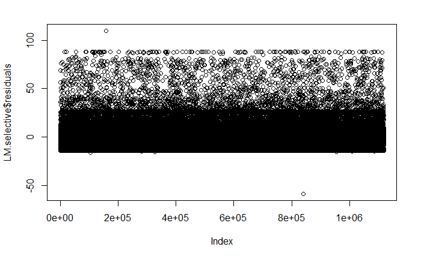

```r
plot(LM.selective$residuals) # plot the residuals against indexes
```

### Provide an estimate of performance using an appropriate sample, and show our work.

*Now we test our multiple linear regression model for performance*

```r
prediction_test <- select(testing.data, tip.to.fare.pct.ratio)
prediction_test <- prediction_test %>% rename(true_value = tip.to.fare.pct.ratio)
prediction_test$LM.prediction <- predict(LM.selective, select(testing.data, dropoff_time, Trip_distance, Fare_amount, Payment_type, Trip_type))
prediction_test$LM.error <- abs(prediction_test$true_value - prediction_test$LM.prediction)
summary(prediction_test$LM.error) # we can see that the mean (is deviated due to data) and median error are pretty acceptable
```

```
   Min. 1st Qu.  Median    Mean 3rd Qu.    Max.    NA's
 0.0000  0.6976  0.8592  3.1744  3.0927 96.2049    1022
```

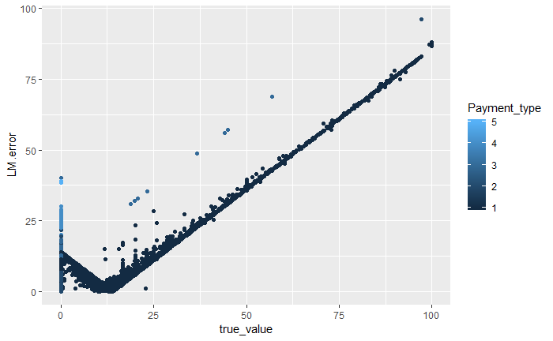

```r
Payment_type <- as.numeric(testing.data$Payment_type)
new.prediction.test <- data.frame(prediction_test, Payment_type) # add payment method info to the prediction results, to use while visualizing later
ggplot(new.prediction.test, aes(x=true_value, y=LM.error, color=Payment_type)) + geom_point()
```

*As seen here, we get an acceptable prediction of the tip to fare ratio for the lower values, and the error starts climbing as the ratio increases by itself (beyond 20 or so).* *Thus, this model cannot be used to predict unusually high tip amounts. It can provide acceptable performance for low tip amounts.*

*We also try a conditional tree model (binary).*

[figure not shown]

```r
library(party)
data.for.prediction <- select(training.data, Trip_distance, Fare_amount, Tip_amount, Payment_type, Trip_type, tip.to.fare.pct.ratio)
data.for.prediction <- na.omit(data.for.prediction)
Tree.selective <- ctree(tip.to.fare.pct.ratio ~ Trip_distance + Fare_amount + Payment_type + Trip_type, data = data.for.prediction)
plot(Tree.selective)
```

*Now we test the performance of our tree model -*

```r
new.prediction.test$tree.prediction <- treeresponse(Tree.selective, select(testing.data, Trip_distance, Fare_amount, Payment_type, Trip_type))
new.prediction.test$tree.prediction <- as.numeric(new.prediction.test$tree.prediction)
new.prediction.test$tree.error <- abs(new.prediction.test$true_value - new.prediction.test$tree.prediction)
summary(new.prediction.test$tree.error)
```

```
   Min. 1st Qu.  Median    Mean 3rd Qu.    Max.    NA's
  0.000   0.000   0.000   2.590   2.911  97.213    1020
```

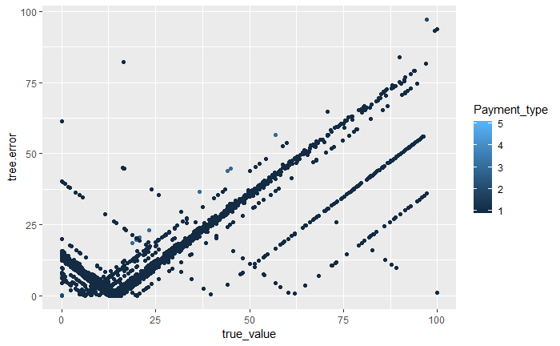

```r
ggplot(new.prediction.test, aes(x=true_value, y=tree.error, color=Payment_type)) + geom_point()
```

*As seen above the decision tree model also ends up giving us a debatably more-reliable estimate of the tip to fare ratio.*  
*We can see that this model results in lower mean and median (= zero!) errors in predicting the ratio across our test dataset.*

*(Given more time at hand, I would train a Random Forest model to assess for performance improvements - if any)*

## —————————————————————————————————————————————————————-

# Question 5 (Option A: Distributions) >

### Build a derived variable representing the average speed over the course of a trip.

```r
data$Trip_duration <- difftime(data$Lpep_dropoff_datetime, data$lpep_pickup_datetime, units = "hours")
data$Trip_duration <- as.numeric(data$Trip_duration)
data$Average_trip_speed <- data$Trip_distance/data$Trip_duration
summary(data$Average_trip_speed) # has infinite values for average trip speed
```

```
   Min. 1st Qu.  Median    Mean 3rd Qu.    Max.    NA's
  0.000   9.314  11.768     Inf  15.066     Inf     937
```

```r
data.with.valid.speeds <- subset(data, is.finite(data$Average_trip_speed)) # so, we filter out the rows with infinite speed values, and use this going forward
```

### Can we perform a test to determine if the average trip speeds are materially the same in all weeks of September? If we decide they are not the same, can we form a hypothesis regarding why they differ?

```r
# 1 week = 168 hours
av.speed.over.week.1 <- aggregate(Average_trip_speed ~ cut(lpep_pickup_datetime, breaks = "168 hours"), data = data.with.valid.speeds, FUN = mean) # using pickup time
av.speed.over.week.1 <- av.speed.over.week.1 %>% rename(week.beginning.from = 'cut(lpep_pickup_datetime, breaks = "168 hours")')
av.speed.over.week.1
```

| week.beginning.from | Average_trip_speed |
| --- | --- |
| 2015-09-01 | 16.24612 |
| 2015-09-08 | 15.11984 |
| 2015-09-15 | 15.21199 |
| 2015-09-22 | 16.35689 |
| 2015-09-29 | 16.97610 |

```r
av.speed.over.week.2 <- aggregate(Average_trip_speed ~ cut(Lpep_dropoff_datetime, breaks = "168 hours"), data = data.with.valid.speeds, FUN = mean) # using dropoff time
av.speed.over.week.2 <- av.speed.over.week.2 %>% rename(week.beginning.from = 'cut(Lpep_dropoff_datetime, breaks = "168 hours")')
av.speed.over.week.2
```

| week.beginning.from | Average_trip_speed |
| --- | --- |
| 2015-09-01 | 16.24874 |
| 2015-09-08 | 15.12975 |
| 2015-09-15 | 15.21159 |
| 2015-09-22 | 16.35521 |
| 2015-09-29 | 16.92932 |

*We wanted to know if trip speeds are essentially the same in all weeks of September - as seen above, they are indeed more or less similar throughout the month.*  
*From my perspective, a deviation of one or two miles per hour is not significant enough to justify a deeper analysis into causes and reasons.*

### Can we build up a hypothesis of average trip speed as a function of time of day?

```r
av.speed.over.time.of.day <- aggregate(Average_trip_speed ~ cut(pickup_time, breaks = "1 hour", labels = FALSE), data = data.with.valid.speeds, FUN = mean)
av.speed.over.time.of.day <- av.speed.over.time.of.day %>% rename(Nth.hour.of.day = 'cut(pickup_time, breaks = "1 hour", labels = FALSE)')
av.speed.over.time.of.day
```

| Nth.hour.of.day | Average_trip_speed |
| --- | --- |
| 1 | 17.62778 |
| 2 | 17.92096 |
| 3 | 18.49187 |
| 4 | 19.04424 |
| 5 | 19.51380 |
| 6 | 29.09118 |
| 7 | 20.83723 |
| 8 | 15.79476 |
| 9 | 15.51255 |
| 10 | 14.84076 |

[output cut: 14 more lines]

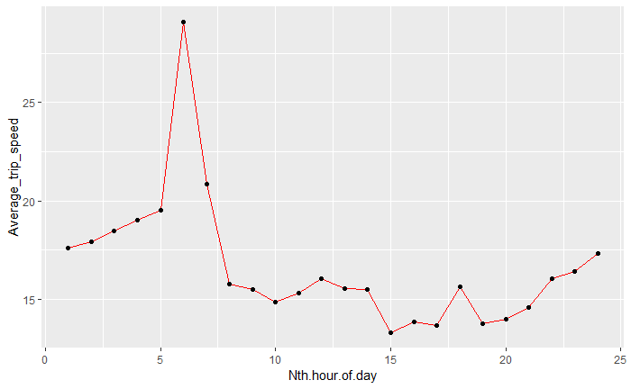

```r
p2 <- ggplot(av.speed.over.time.of.day, aes(x=Nth.hour.of.day)) + geom_line(aes(y=Average_trip_speed), color="red") + geom_point(aes(y=Average_trip_speed))
p2
```

*As we can see from the plot, taxi trips are slowest in the time frame when people finish work and travel back home (the 3pm to 8pm window)*

*This hypothesis is specific, and can be tested using the dataset we have worked on here.*

## —————————————————————————————————————————————————————-